# AMS 580 Final Exam Part 2

## Best $\lambda$ for LASSO is $\lambda_{min}=8.009019$

```r
model2 <- glmnet(x, y, alpha = 1, lambda = cv$lambda.min) # alpha=1: LASSO
coef(model)
```

[output not shown]

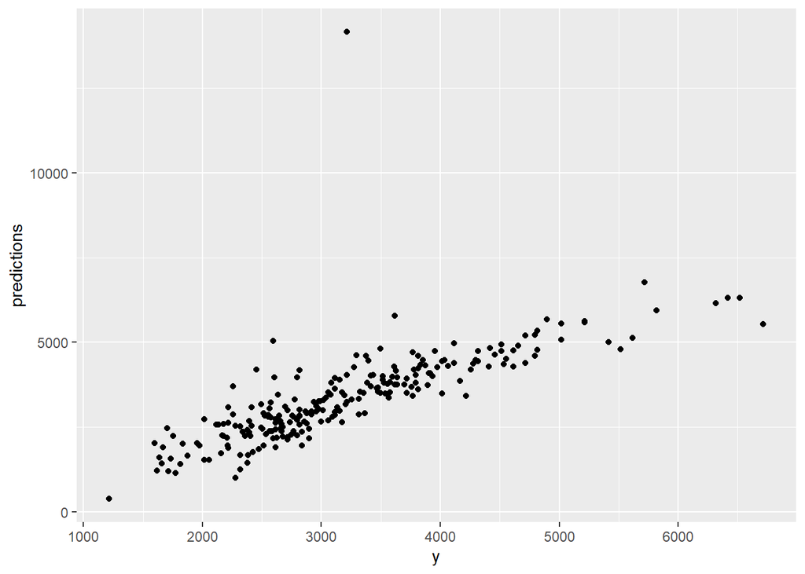

```r
x.test <- model.matrix(y ~., test)[,-1]
predictions <- model2 %>% predict(x.test) %>% as.vector()

ggplot(data = test, aes(x = y, y = predictions)) + geom_point()
```

```r
data.frame(
 RMSE = RMSE(predictions, test$y),
 Rsquare = R2(predictions, test$y)
)
```

```
##       RMSE   Rsquare
## 1 887.0573 0.5726799
```

## RMSE is 887.0573 and coefficient of determination is 0.5726799.

# **Part c** Please first find the best Elastic Net model using the training data. Please (a) find the best tuning parameter values through cross-validation and display these values; (b) display the coefficients of the fitted model; and (c) make prediction on the testing data, plot the observed response variable on the x-axis, and the estimated response variable on the Y-axis, and report the RMSE and the Coefficient of Determination R^2.

```r
model <- train(
  y ~., data = train, method = "glmnet",
  trControl = trainControl("cv", number = 10),
  tuneLength = 10
)
model$bestTune
```

```
##    alpha   lambda
## 83     1 3.294129
```

```r
coef(model$finalModel, model$bestTune$lambda)
```

```
## 15 x 1 sparse Matrix of class "dgCMatrix"
##                        1
## (Intercept) -992.7045941
## w1           400.2977434
## w2            34.2038287
## w3             0.6013350
## w4Y          -25.6165819
## w5             1.8838951
## w6             1.1184492
## w7            13.1930217
## w8           112.1379955
## w9          -170.6008544
## w10         -567.6934207
## w11           64.3630106
## w12           76.8927201
## w13            0.7327803
## w14           -7.2993011
```

```r
predictions <- model %>% predict(test)
data.frame(
  RMSE = RMSE(predictions, test$y),
  Rsquare = R2(predictions, test$y)
)
```

```
##       RMSE   Rsquare
## 1 896.5528 0.5697739
```

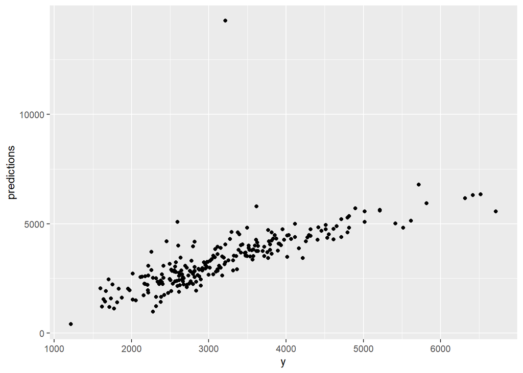

```r
ggplot(data = test, aes(x = y, y = predictions)) + geom_point()
```

## RMSE is 896.5528 and coefficient of determination is 0.5697739.

# **Part d** Please discuss which penalized regression method is the best for the QuestionMark.csv data, and why.

# The ridge regression model is best as it has the lowest RMSE and highest coefficient of determination.

# 3. Now we shall perform variable selection using the best subset method, and the stepwise variable selection method. Please identify the best models (either the best subset model, or the best stepwise regression model) using the same training data as in Question 2 above, only

# (a) We shall use ‘y’ as the response variables, and there are a total of 14 regressors to choose from. First, please use the R function regsubsets() [leaps package] for best-subset variable selection to identify different best models of different sizes ranging from 1 to 6.

```r
train.data<-train
test.data<-test

models <- regsubsets(y~., data = train.data, nvmax = 6)
summary(models)
```

```
## Subset selection object
## Call: regsubsets.formula(y ~ ., data = train.data, nvmax = 6)
## 14 Variables  (and intercept)
##     Forced in Forced out
## w1      FALSE      FALSE
## w2      FALSE      FALSE
## w3      FALSE      FALSE
## w4Y     FALSE      FALSE
## w5      FALSE      FALSE
## w6      FALSE      FALSE
## w7      FALSE      FALSE
## w8      FALSE      FALSE
## w9      FALSE      FALSE
## w10     FALSE      FALSE
## w11     FALSE      FALSE
## w12     FALSE      FALSE
## w13     FALSE      FALSE
## w14     FALSE      FALSE
## 1 subsets of each size up to 6
## Selection Algorithm: exhaustive
##          w1  w2  w3  w4Y w5  w6  w7  w8  w9  w10 w11 w12 w13 w14
## 1  ( 1 ) "*" " " " " " " " " " " " " " " " " " " " " " " " " " "
## 2  ( 1 ) "*" " " " " " " "*" " " " " " " " " " " " " " " " " " "
## 3  ( 1 ) "*" " " " " " " "*" "*" " " " " " " " " " " " " " " " "
## 4  ( 1 ) "*" " " " " " " "*" "*" " " " " " " " " " " " " "*" " "
## 5  ( 1 ) "*" " " " " " " "*" "*" " " " " " " "*" " " " " "*" " "
## 6  ( 1 ) "*" " " " " " " "*" "*" " " " " "*" "*" " " " " "*" " "
```

# (b) Please use the 5-fold cross-validation to select the best overall model from all 6 best subset models identified in part (a) above. Please write down the equation of this best overall model.

```r
get_model_formula <- function(id, object, outcome){
  # get models data
  models <- summary(object)$which[id,-1]
  # Get outcome variable
  #form <- as.formula(object$call[[2]])
  #outcome <- all.vars(form)[1]
  # Get model predictors
  predictors <- names(which(models == TRUE))
  predictors <- paste(predictors, collapse = "+")
  # Build model formula
  as.formula(paste0(outcome, "~", predictors))
}

get_cv_error <- function(model.formula, data){
  set.seed(1)
  train.control <- trainControl(method = "cv", number = 5)
  cv <- train(model.formula, data = data, method = "lm",
              trControl = train.control)
  cv$results$RMSE
}

model.ids <- 1:6
cv.errors <-  map(model.ids, get_model_formula, models, "y") %>%
  map(get_cv_error, data = train.data) %>%
  unlist()
cv.errors
```

```
## [1] 1003.4396  891.2064  800.2131  777.8699  761.2625  750.1992
```

```r
which.min(cv.errors)
```

```
## [1] 6
```

```r
bestsubcv<-lm(y ~ w1+w5+w6+w9+w10+w13, data = train.data)

preds<-predict(bestsubcv,test.data)

data.frame(
  RMSE = RMSE(preds, test$y),
  Rsquare = R2(preds, test$y)
)
```

```
##       RMSE   Rsquare
## 1 931.7097 0.5414659
```

# The overall best model is the model with 6 variables:

# y~w1+w5+w6+w9+w10+w13

# (c) Please use the R function stepAIC() [MASS package] to identify the best model using the stepwise variable selection method. Please write down the equation of this best overall model.

```r
res.lm <- lm(y ~., data = train.data)
step <- stepAIC(res.lm, direction = "both", trace = FALSE)
step
```

```
##
## Call:
## lm(formula = y ~ w1 + w2 + w3 + w5 + w6 + w8 + w9 + w10 + w11 +
##     w13 + w14, data = train.data)
##
## Coefficients:
## (Intercept)           w1           w2           w3           w5           w6
##   -971.9209     401.7761      32.2734       0.6119       1.9125       1.1519
##          w8           w9          w10          w11          w13          w14
##    114.2484    -180.3963    -564.9303      66.2409       0.9380      -7.6334
```

```r
preds<-predict(step,test.data)

data.frame(
  RMSE = RMSE(preds, test$y),
  Rsquare = R2(preds, test$y)
)
```

```
##       RMSE   Rsquare
## 1 914.4046 0.5614957
```

# (d) Compare to Question 2, the penalized regression methods above, which variable selection method is the overall best, based on what criterion (or criteria) of your choice? Please perform this comparison using the same testing data as in Question 2 above

# The Ridge regression method produced the best model with the lowest RMSE of 825.9467 and highest Rsquared of 0.603015 on new data